# Homework6-solutions

Hakan Gogtas

11/6/2020

## R Markdown

### Due Date: November 3, 2020 at 7:20 pm EST

### Instructions

Students should submit their reports on Canvas. The report needs to clearly state what question is being solved, step-by-step walk-through solutions, and final answers clearly indicated. Please solve by hand where appropriate.

Please submit two files: (1) a R Markdown file (.Rmd extension) and (2) a PDF document, word, or html generated using knitr for the .Rmd file submitted in (1) where appropriate. Please, use RStudio Cloud for your solutions.

## Solutions:

## Problem 1

Refer to Commercial properties data set. A commercial real estate company evaluates vacancy rates, square footage, rental rates, and operating expenses for commercial properties in a large metropolitan area in order to provide clients with quantitative information upon which to make rental decisions.The variables in the data set are the age ($X_1$), operating expenses and taxes ($X_2$), vacancy rates ($X_3$), total square footage ($X_4$),and rental rates (Y). (35 points, 5 points each)

a-) Obtain the scatter plot matrix and the correlation matrix. Interpret these and state your principal findings.

$X_4$ is the variable that is strongly more correlated with Y than other variables. The correlation coefficient is 0.54. $X_2$ follows $X_4$ wih the correlation coefficent of 0.41. There also indication of some outliers with $X_3$.

```r
install.packages("readr")
library(readr)
Commercial_Properties_Data_Set <- read_csv("Commercial Properties Data Set.csv")
CPDS <-data.frame(Commercial_Properties_Data_Set)
head(CPDS)
```

```
##      Y X1    X2   X3     X4
## 1 13.5  1  5.02 0.14 123000
## 2 12.0 14  8.19 0.27 104079
## 3 10.5 16  3.00 0.00  39998
## 4 15.0  4 10.70 0.05  57112
## 5 14.0 11  8.97 0.07  60000
## 6 10.5 15  9.45 0.24 101385
```

```r
#Use the cor() R function to obtain the correlation matrix and the plot() R function to obtain the scatter plot matrix.
round(cor(CPDS ),2)
```

```
##        Y    X1    X2    X3   X4
## Y   1.00 -0.25  0.41  0.07 0.54
## X1 -0.25  1.00  0.39 -0.25 0.29
## X2  0.41  0.39  1.00 -0.38 0.44
## X3  0.07 -0.25 -0.38  1.00 0.08
## X4  0.54  0.29  0.44  0.08 1.00
```

```r
par(frow=c(1,1))
```

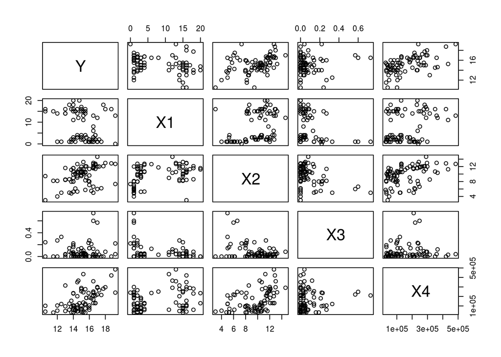

```r
plot(CPDS)
```

b-) Fit regression model for four predictor variables to the data. State the estimated regression function.

All variables are significant except $X_3$.$R^2$ is 58%. The estimated regression function is below:

Y= 12.2 - 0.14 $X_1$ + 0.28 $X_2$ + 0.62 $X_3$ + 0.000008 $X_4$

#Use the lm() R function to fit the regression model for the four predictor variables: X1,X2,X3,and X4 to the rental rates response variable, Y. #not to display numbers such as 1+e3 (exponent), changing the option

```r
options("scipen" = 10)
h<-lm(Y~.,data=CPDS )
summary(h)
```

```
##
## Call:
## lm(formula = Y ~ ., data = CPDS)
##
## Residuals:
##     Min      1Q  Median      3Q     Max
## -3.1872 -0.5911 -0.0910  0.5579  2.9441
##
## Coefficients:
##                 Estimate   Std. Error t value      Pr(>|t|)
## (Intercept) 12.200585882  0.577956174  21.110       < 2e-16 ***
## X1          -0.142033644  0.021342610  -6.655 0.00000000389 ***
## X2           0.282016530  0.063172350   4.464 0.00002747396 ***
## X3           0.619343503  1.086812829   0.570          0.57
## X4           0.000007924  0.000001385   5.722 0.00000019760 ***
## ---
## Signif. codes:  0 '***' 0.001 '**' 0.01 '*' 0.05 '.' 0.1 ' ' 1
##
## Residual standard error: 1.137 on 76 degrees of freedom
## Multiple R-squared:  0.5847, Adjusted R-squared:  0.5629
## F-statistic: 26.76 on 4 and 76 DF,  p-value: 0.00000000000007272
```

```r
anova(h)
```

```
## Analysis of Variance Table
##
## Response: Y
##           Df Sum Sq Mean Sq F value           Pr(>F)
## X1         1 14.819  14.819 11.4649         0.001125 **
## X2         1 72.802  72.802 56.3262 0.00000000009699 ***
## X3         1  8.381   8.381  6.4846         0.012904 *
## X4         1 42.325  42.325 32.7464 0.00000019759897 ***
## Residuals 76 98.231   1.293
## ---
## Signif. codes:  0 '***' 0.001 '**' 0.01 '*' 0.05 '.' 0.1 ' ' 1
```

c-) Obtain the residuals and prepare a box plot of the residuals. Does the distribution appear to be fairly symmetrical?

Yes, it appears to be fairly symmetrical. However, there are out-liers.

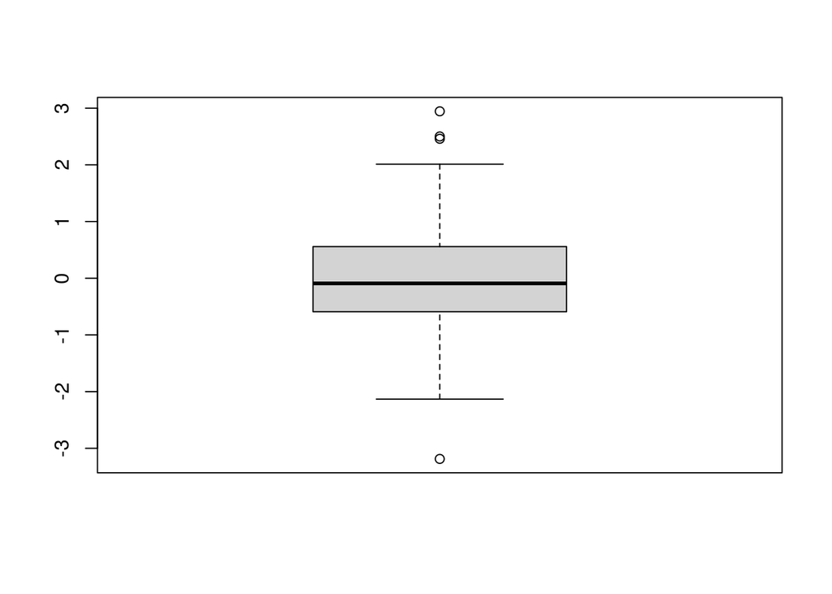

```r
# Use the boxplot () R function to prepare a box plot of the residuals.
ei<-h$residuals
boxplot(ei)
```

d-)Conduct the Breusch-Pagan test for constancy of the error variance, assuming log $\sigma_{i}^{2}$=$\gamma_0$+$\gamma_1X_1$+$\gamma_2X_2$+$\gamma_3X_3$+$\gamma_4X_4$ use $\alpha$ = .01. State the alternatives, decision rule, and conclusion.

The Breusch-Pagan test can be modified to allow for different relationships between the error variance and the level of X (Refer to Chapter 3 page #119 of the Michael_H_Kutner,et. al.) As the errors were fairly symmetric we choose not to apply logs to the squared residuals to estimate the variance. If the squared errors looked more disperse we may have decided to use natural log of the residuals instead. If you justified your analysis you will be granted full points here.

H_{0}:$\gamma_{1}= \gamma_{2} = \gamma_{3}= \gamma_{4}=0$ H_{a}:At least one $\gamma_{i} \neq 0$

The decision rule is: If p-value > alpha, conclude Ho.Conclusion: The p-value of the test is 0.04 > alpha (0.01). Thus, we conclude Ho: error variance is constant. Fail to reject the null; error variances are equal.

```r
ei2<-ei^2
CPDS[ ,6]<-ei2
dimnames(CPDS)[[2]][6]<-"ei2"
h2<-lm(ei2~X1+X2+X3+X4,data=CPDS)
summary(h2)
```

```
##
## Call:
## lm(formula = ei2 ~ X1 + X2 + X3 + X4, data = CPDS)
##
## Residuals:
##     Min      1Q  Median      3Q     Max
## -2.6219 -1.0352 -0.2229  0.3075  8.6492
##
## Coefficients:
##                 Estimate   Std. Error t value Pr(>|t|)
## (Intercept)  2.428284801  0.930512818   2.610  0.01091 *
## X1           0.071930860  0.034361727   2.093  0.03965 *
## X2          -0.273126482  0.101707852  -2.685  0.00889 **
## X3           0.195251472  1.749775006   0.112  0.91145
## X4           0.000005286  0.000002229   2.371  0.02029 *
## ---
## Signif. codes:  0 '***' 0.001 '**' 0.01 '*' 0.05 '.' 0.1 ' ' 1
##
## Residual standard error: 1.83 on 76 degrees of freedom
## Multiple R-squared:  0.1602, Adjusted R-squared:  0.116
## F-statistic: 3.625 on 4 and 76 DF,  p-value: 0.009308
```

```r
d<-anova(h2)
#Under H_0 the test statistic of the Breusch-Pagan test follows a chi-squared distribution with parameter (the number of regressors without the constant in the model) degrees of freedom (here is 4). Note that here we chose not to transform the squared residuals by taking logs.
SSR=  sum(d$`Sum Sq`[1:4])
SSE=  98.231
Chi.Square=(SSR/4)/((SSE/81)^2)
1-pchisq(Chi.Square,3)
```

```
## [1] 0.04097494
```

#Alternatively you may use BP function.To perform the Breusch-Pagan test, proceed to use the bptest() R function of the lmtest R package.library(lmtest). The null hypothesis of the Breusch-Pagan test is homoscedasticity (= variance does not depend on auxiliary regressors). If the p-value becomes “small”, the null hypothesis is rejected. Answer does not change but the exact p-value may differ because of the transformation technique applied to the residuals.

```r
install.packages("lmtest")
library(lmtest)
bptest(h)$p.value[["BP"]]>0.01
```

```
## [1] TRUE
```

e-) Obtain QQ plot and error vs. fitted values, and comment on the graphs.

QQ plot shows heavy tails. Difficult to detect unequal variances from the residual vs fitted values graph. Heteroscedasticity could be due to the heavy tails.

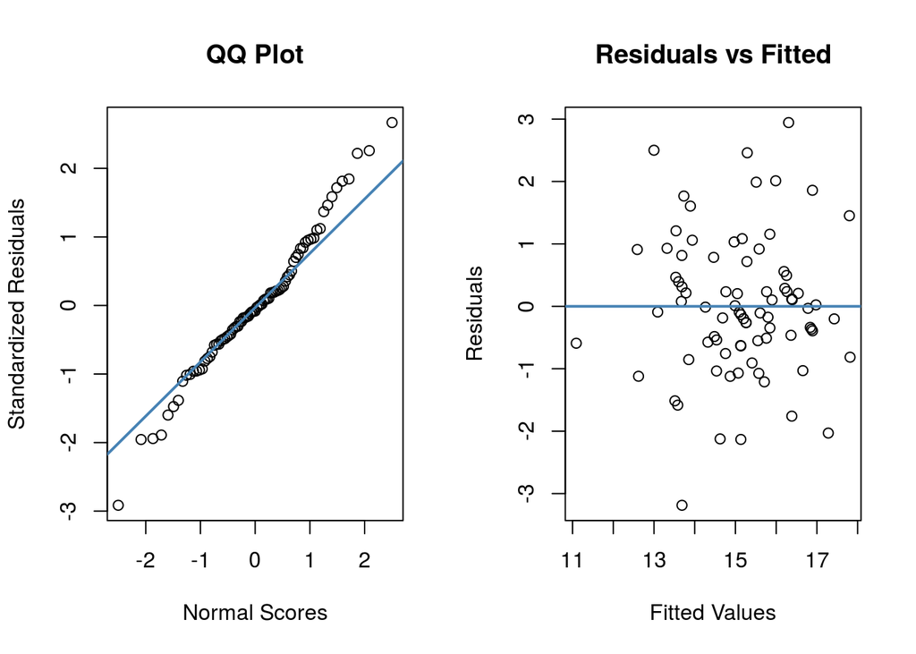

```r
#To prepare a normal probability (QQ) plot of the residuals $\epsilon_{i}$, use the **qqnorm()** R function and the **qqline()** R function together.
par(mfrow=c(1,2))
stdei<- rstandard(h)
qqnorm(stdei,ylab="Standardized Residuals",xlab="Normal Scores", main="QQ Plot")
qqline(stdei,col = "steelblue", lwd = 2)
#Use the **plot()** R function together with the **abline()** R function as follows to plot the residuals $e_i$ against the fitted values $\hat Y_i$.
plot(h$fitted.values,h$residuals,xlab="Fitted Values",ylab="Residuals",main="Residuals vs Fitted")
abline(h=0,col="steelblue",lwd=2)
```

f-) Estimate $\beta_0$, $\beta_1$, $\beta_2$, $\beta_3$ and $\beta_4$ jointly by the Bonferroni procedure, using a 95 percent family confidence coefficient. Interpret your results.

```r
#To obtain the Bonferroni joint confidence intervals of $\beta_{0}$, $\beta_{1}$, $\beta_{2}$, $\beta_{3}$, and $\beta_{4}$, use the **confint()** R function for a 95 percent family confidence coefficient.
confint(h,level=1-0.05/4)
```

```
##                     0.625 %       99.375 %
## (Intercept) 10.721861129330 13.67931063462
## X1          -0.196639592601 -0.08742769442
## X2           0.120387462891  0.44364559701
## X3          -2.161312025259  3.39999903219
## X4           0.000004381297  0.00001146731
```

g-) $X_1$=5, $X_2$=8.25, $X_3$=0 and $X_4$=250000, calculate the predicted rental rate and 95% confidence interval Please see below.

```r
predict(h,data.frame(X1=5,X2=8.25,X3=0,X4=250000),level=0.95, interval = "confidence")
```

```
##        fit      lwr      upr
## 1 15.79813 15.24428 16.35198
```

## Problem 2

Refer to the CDI data set. You have been asked to evaluate two alternative models for predicting the number of active ve physicians (Y) in a CDI. Proposed model I includes as predictor variables total population ($X_1$), land area ($X_2$), and total personal income ($X_3$). Proposed model II includes as predictor variables population density ($X_1$, total population divided by land area), percent of population greater than 64 years old ($X_2$), and total personal income ($X_3$).(40 points, 10 points each)

a-) Obtain the scatter plot matrix and the correlation matrix for each proposed model. Summarize the information provided.

For the first model, the number of active ve physicians (Y) is highly correlated with both Total.personal.income and Total.population. Also, Total.personal.income and Total.population are highly correlated with each other.

```r
CDI <- read_csv("CDI Data.csv")
CDI<-data.frame(CDI)
head(CDI)
```

```
##   Identification.number      County State Land.area Total.population
## 1                     1 Los_Angeles    CA      4060          8863164
## 2                     2        Cook    IL       946          5105067
## 3                     3      Harris    TX      1729          2818199
## 4                     4   San_Diego    CA      4205          2498016
## 5                     5      Orange    CA       790          2410556
## 6                     6       Kings    NY        71          2300664
##   Percent.of.population.aged.18.34 Percent.of.population.65.or.older
## 1                             32.1                               9.7
## 2                             29.2                              12.4
## 3                             31.3                               7.1
## 4                             33.5                              10.9
## 5                             32.6                               9.2
## 6                             28.3                              12.4
##   Number.of.active.physicians Number.of.hospital.beds Total.serious.crimes
```

[output cut: 27 more lines]

```r
Population.density=CDI$Total.population/CDI$Land.area
CDI[,18]=Population.density
dimnames(CDI)[[2]][18]<-"Population.density"


m.d1<-data.frame(CDI$Number.of.active.physicians,CDI$Total.population,CDI$Land.area,CDI$Total.personal.income)
m.d2<-data.frame(CDI$Number.of.active.physicians,CDI$Population.density,CDI$Percent.of.population.65.or.older,CDI$Total.personal.income)

round(cor(m.d1),2)
```

```
##                                 CDI.Number.of.active.physicians
## CDI.Number.of.active.physicians                            1.00
## CDI.Total.population                                       0.94
## CDI.Land.area                                              0.08
## CDI.Total.personal.income                                  0.95
##                                 CDI.Total.population CDI.Land.area
## CDI.Number.of.active.physicians                 0.94          0.08
## CDI.Total.population                            1.00          0.17
## CDI.Land.area                                   0.17          1.00
## CDI.Total.personal.income                       0.99          0.13
##                                 CDI.Total.personal.income
## CDI.Number.of.active.physicians                      0.95
## CDI.Total.population                                 0.99
## CDI.Land.area                                        0.13
## CDI.Total.personal.income                            1.00
```

```r
round(cor(m.d2),2)
```

```
##                                       CDI.Number.of.active.physicians
## CDI.Number.of.active.physicians                                  1.00
## CDI.Population.density                                           0.41
## CDI.Percent.of.population.65.or.older                            0.00
## CDI.Total.personal.income                                        0.95
##                                       CDI.Population.density
## CDI.Number.of.active.physicians                         0.41
## CDI.Population.density                                  1.00
## CDI.Percent.of.population.65.or.older                   0.03
## CDI.Total.personal.income                               0.32
##                                       CDI.Percent.of.population.65.or.older
## CDI.Number.of.active.physicians                                        0.00
## CDI.Population.density                                                 0.03
## CDI.Percent.of.population.65.or.older                                  1.00
## CDI.Total.personal.income                                             -0.02
##                                       CDI.Total.personal.income
## CDI.Number.of.active.physicians                            0.95
## CDI.Population.density                                     0.32
## CDI.Percent.of.population.65.or.older                     -0.02
## CDI.Total.personal.income                                  1.00
```

b-) For each proposed model, fit the first-order regression model with three predictor variables.

```r
m1<-lm(Number.of.active.physicians~Total.population+Land.area+Total.personal.income,data=CDI)
m1s<-summary(m1)
m2<-lm(Number.of.active.physicians~Population.density+Percent.of.population.65.or.older+Total.personal.income,data=CDI)
m2s<-summary(m2)
```

c-) Calculate $R^2$ for each model. Is one model clearly preferable in terms of this measure?

```r
r1=min(summary(m1s$adj.r.squared[1]))
r2=min(summary(m2s$adj.r.squared[1]))
cbind(r1,r2)
```

```
##             r1        r2
## [1,] 0.9019733 0.9111419
```

See above, no one is clearly preferable, $R^2$ are close to each other.

d-) For each model, obtain the residuals and plot them against $\hat{Y}$, each of the three predictor variables. Also prepare a normal probability plot for each of the two fitted models. Interpret your plots and state your findings. Is one model clearly preferable in terms of appropriateness?

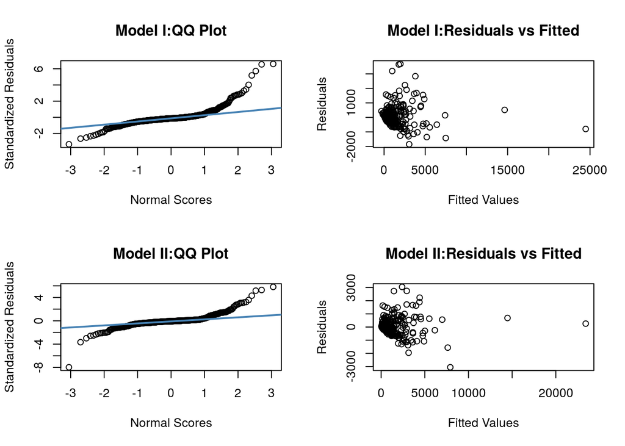

```r
par(mfrow=c(2,2))
stdei<- rstandard(m1)
qqnorm(stdei,ylab="Standardized Residuals",xlab="Normal Scores", main="Model I:QQ Plot")
qqline(stdei,col = "steelblue", lwd = 2)
plot(m1$fitted.values,m1$residuals,xlab="Fitted Values",ylab="Residuals",main="Model I:Residuals vs Fitted")

stdei<- rstandard(m2)
qqnorm(stdei,ylab="Standardized Residuals",xlab="Normal Scores", main="Model II:QQ Plot")
qqline(stdei,col = "steelblue", lwd = 2)
plot(m2$fitted.values,m2$residuals,xlab="Fitted Values",ylab="Residuals",main="Model II:Residuals vs Fitted")
```

## Problem 3

Refer to Grocery retailer data set.A large, national grocery retailer tracks productivity and costs of its facilities closely. Each data point for each variable represents one week of activity. The variables included are the number of cases shipped ($X_1$),the indirect costs of the total labor hours as a percentage ($X_2$), a qualitative predictor called holiday that is coded 1 if the week has a holiday and 0 otherwise ($X_3$), and the total labor hours (Y). (25 points, 5 points each)

a-) Fit regression model to the data for three predictor variables. State the estimated regression function. How are $b_1$, $b_2$ , and $b_3$ interpreted here? (5 points)

There is a strong correlation between X3 and Y. As it can be seen from the boxplot, Y has two separate ranges (or distributions) for X3=1 and X3=0. X1 and X3 are significant.$R^2$ is 68%. The estimated regression function is below:

Y= 4149.88 + 0.00078 $X_1$ - 13.17 $X_2$ + 623.55 $X_3$

Changing X3=0 to X3=1 will increase the total hours by 623.55 by holding all the variables are constant. You can make the similar explanations for other variables.

```r
library(readr)
Grocery_Retailer_Data_Set <- read_csv("Grocery Retailer Data Set.csv")
GRDS <- data.frame(Grocery_Retailer_Data_Set)
head(GRDS)
```

```
##      Y     X1   X2 X3
## 1 4264 305657 7.17  0
## 2 4496 328476 6.20  0
## 3 4317 317164 4.61  0
## 4 4292 366745 7.02  0
## 5 4945 265518 8.61  1
## 6 4325 301995 6.88  0
```

```r
round(cor(GRDS),2)
```

```
##       Y   X1   X2   X3
## Y  1.00 0.21 0.06 0.81
## X1 0.21 1.00 0.08 0.05
## X2 0.06 0.08 1.00 0.11
## X3 0.81 0.05 0.11 1.00
```

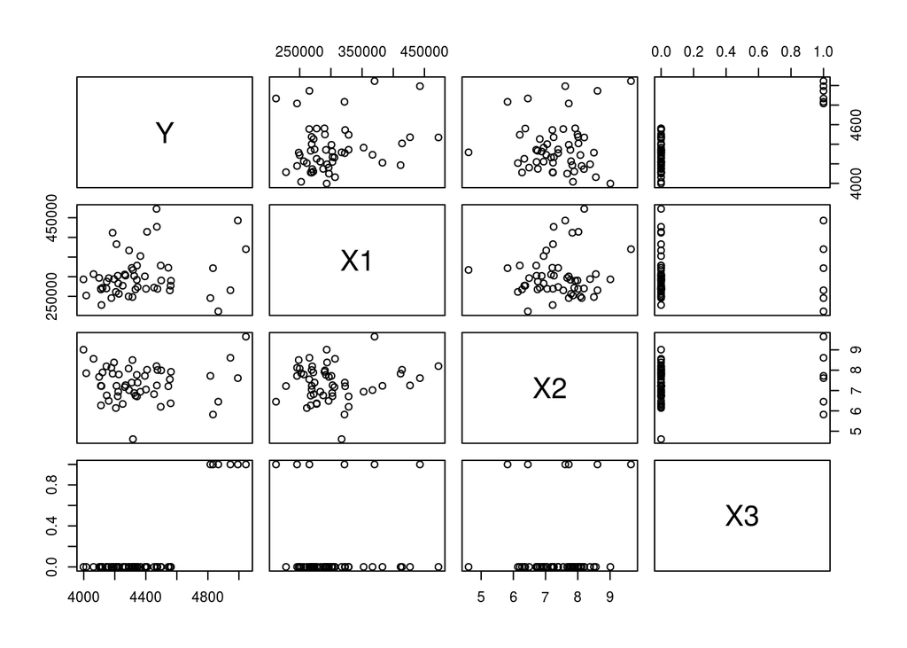

```r
plot(GRDS)
```

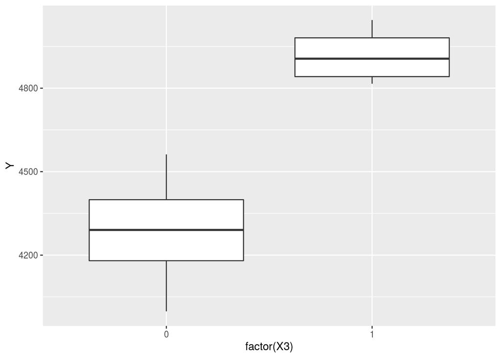

```r
#install.packages("plyr") # This package is useful as a data manipulator
#install.packages("ggplot2") #This package is useful for visualizing data
library(plyr)
library(ggplot2)
#you need to define X3 as a factor to see the side by side boxplot
ggplot(GRDS, aes(x = factor(X3), y = Y)) + geom_boxplot()
```

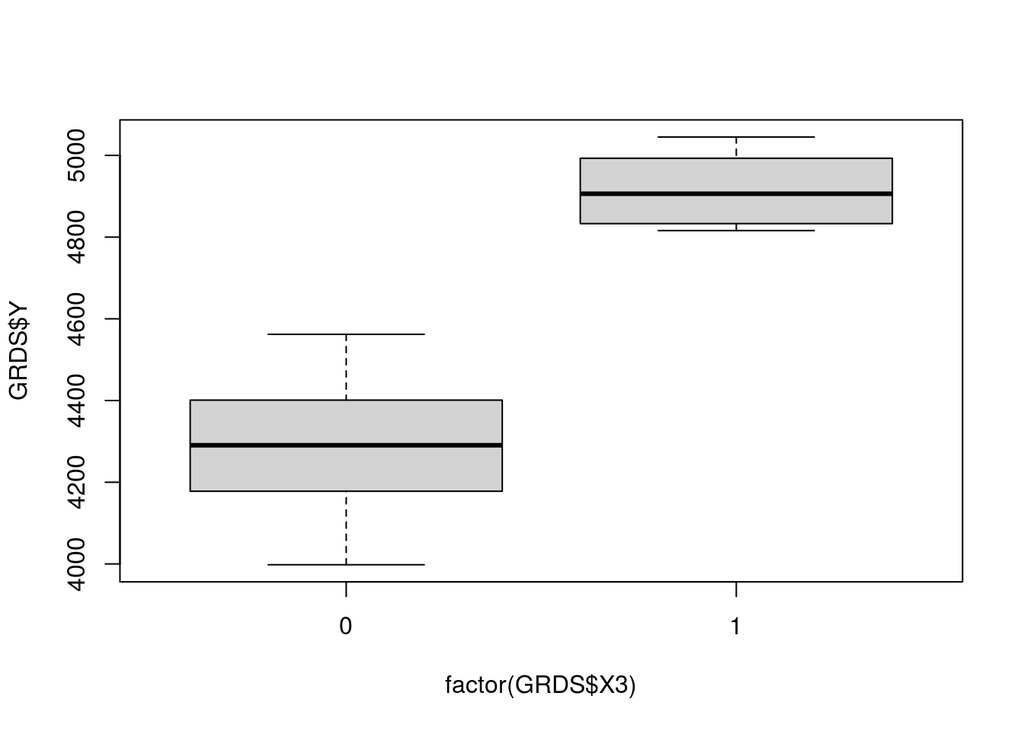

```r
#alternatively you can use the code below as well for the boxplot
boxplot(GRDS$Y~factor(GRDS$X3))
```

```r
#not to display numbers such as 1+e3 (exponent), changing the option
options("scipen" = 10)
f1<-lm(Y~.,data=GRDS)
summary(f1)
```

```
##
## Call:
## lm(formula = Y ~ ., data = GRDS)
##
## Residuals:
##     Min      1Q  Median      3Q     Max
## -264.05 -110.73  -22.52   79.29  295.75
##
## Coefficients:
##                 Estimate   Std. Error t value          Pr(>|t|)
## (Intercept) 4149.8872120  195.5654055  21.220           < 2e-16 ***
## X1             0.0007871    0.0003646   2.159            0.0359 *
## X2           -13.1660192   23.0917315  -0.570            0.5712
## X3           623.5544807   62.6409466   9.954 0.000000000000294 ***
## ---
## Signif. codes:  0 '***' 0.001 '**' 0.01 '*' 0.05 '.' 0.1 ' ' 1
##
## Residual standard error: 143.3 on 48 degrees of freedom
## Multiple R-squared:  0.6883, Adjusted R-squared:  0.6689
## F-statistic: 35.34 on 3 and 48 DF,  p-value: 0.000000000003316
```

```r
anova(f1)
```

```
## Analysis of Variance Table
##
## Response: Y
##           Df  Sum Sq Mean Sq F value             Pr(>F)
## X1         1  136366  136366  6.6417            0.01309 *
## X2         1    5726    5726  0.2789            0.59987
## X3         1 2034514 2034514 99.0905 0.0000000000002941 ***
## Residuals 48  985530   20532
## ---
## Signif. codes:  0 '***' 0.001 '**' 0.01 '*' 0.05 '.' 0.1 ' ' 1
```

b-)Prepare a time plot of the residuals. Is there any indication of that the error terms are correlated?

No indication or correlation. However, there could be a pattern such as every 4 points, the movement is replicating it self. It needs to be investigated further.

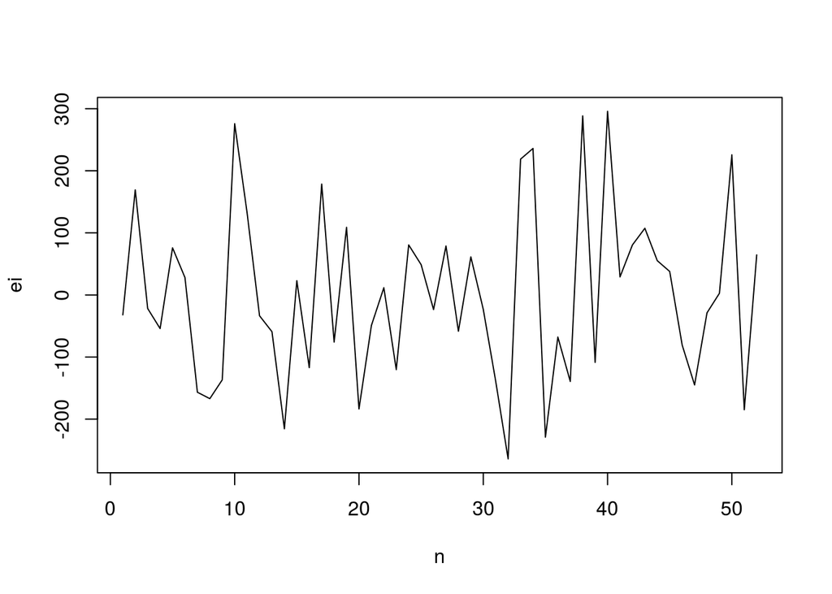

```r
ei<-f1$residuals
n<-seq(1:length(ei))
par(mfrow=c(1,1))
plot(n,ei,type="l")
```

c-) Obtain the analysis of variance table that decomposes the regression sum of squares into extra sums of squares associated with $X_1$; with $X_3$ , given $X_1$; and with $X_2$ , given $X_1$, and $X_3$.

see below:

S($X_1$) = 136366 S($X_3$/$X_1$)= 2033565 S($X_2$/$X_1$,$X_3$)= 6675

```r
#order need to be kept
fz<-lm(Y~X1+X3+X2,data=GRDS)
summary(fz)
```

```
##
## Call:
## lm(formula = Y ~ X1 + X3 + X2, data = GRDS)
##
## Residuals:
##     Min      1Q  Median      3Q     Max
## -264.05 -110.73  -22.52   79.29  295.75
##
## Coefficients:
##                 Estimate   Std. Error t value          Pr(>|t|)
## (Intercept) 4149.8872120  195.5654055  21.220           < 2e-16 ***
## X1             0.0007871    0.0003646   2.159            0.0359 *
## X3           623.5544807   62.6409466   9.954 0.000000000000294 ***
## X2           -13.1660192   23.0917315  -0.570            0.5712
## ---
## Signif. codes:  0 '***' 0.001 '**' 0.01 '*' 0.05 '.' 0.1 ' ' 1
##
## Residual standard error: 143.3 on 48 degrees of freedom
## Multiple R-squared:  0.6883, Adjusted R-squared:  0.6689
## F-statistic: 35.34 on 3 and 48 DF,  p-value: 0.000000000003316
```

```r
anova(fz)
```

```
## Analysis of Variance Table
##
## Response: Y
##           Df  Sum Sq Mean Sq F value             Pr(>F)
## X1         1  136366  136366  6.6417            0.01309 *
## X3         1 2033565 2033565 99.0443 0.0000000000002963 ***
## X2         1    6675    6675  0.3251            0.57123
## Residuals 48  985530   20532
## ---
## Signif. codes:  0 '***' 0.001 '**' 0.01 '*' 0.05 '.' 0.1 ' ' 1
```

d-) Test whether $X_2$ can be dropped from the regression model given that $X_1$, and $X_3$ are retained. Use the F* test statistic and $\alpha$ = .05. State the alternatives, decision rule, and conclusion. What is the P-value of the test?

Ho: $\beta_2$ = 0 Ha: $\beta_2 \neq 0$

Pvalue is 0.57, Accept null. $X_2$ can be dropped from the model.

```r
fr<-lm(Y~X1+X3,data=GRDS)
anova(fr,f1)
```

```
## Analysis of Variance Table
##
## Model 1: Y ~ X1 + X3
## Model 2: Y ~ X1 + X2 + X3
##   Res.Df    RSS Df Sum of Sq      F Pr(>F)
## 1     49 992204
## 2     48 985530  1    6674.6 0.3251 0.5712
```

e-) Does SSR($X_1$)+SSR($X_2$/$X_1$) equal SSR($X_2$)+SSR($X_1$/$X_2$) here? Must this always be the case? (5 points)

#order in lm fuction x2+x1

Yes, always must be equal as it shows the total SSR when both $X_1$ and $X_2$ are in the model.

from the part c: SSR($X_1$) = 136366 SSR($X_2$/$X_1$)= 5726 SSR($X_1$)+ SSR($X_2$/$X_1$) =136366 + 5726=142092 from the r code below: SSR($X_2$) = 11395 SSR($X_1$/$X_2$)= 130697 SSR($X_2$) + SSR($X_1$/$X_2$)=11395+130697=142092

```r
fk<-lm(Y~X1+X2,data=GRDS)
anova(fk)
```

```
## Analysis of Variance Table
##
## Response: Y
##           Df  Sum Sq Mean Sq F value Pr(>F)
## X1         1  136366  136366  2.2125 0.1433
## X2         1    5726    5726  0.0929 0.7618
## Residuals 49 3020044   61634
```

```r
a=136366 + 5726
f22<-lm(Y~X2+X1,data=GRDS)
anova(f22)
```

```
## Analysis of Variance Table
##
## Response: Y
##           Df  Sum Sq Mean Sq F value Pr(>F)
## X2         1   11395   11395  0.1849 0.6691
## X1         1  130697  130697  2.1206 0.1517
## Residuals 49 3020044   61634
```

```r
b=11395+130697

cbind(a,b)
```

```
##           a      b
## [1,] 142092 142092
```